# R Notebook

# How do sites vary in their nutrient resource profiles?

As a starting point, I characterized sites by their resource availability to get a better sense of the variation in resource supply across sites, as well as correlation between the three potential limiting resources manipulated through fertilization.

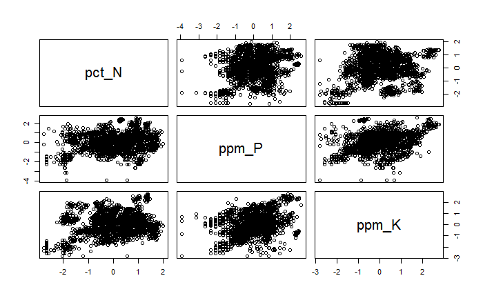

```
            pct_N      ppm_P      ppm_K       pct_C
pct_N  19.0516250 -0.4135064 -1.2377120 -18.2352637
ppm_P  -0.4135064  1.1466961 -0.3017573   0.2167122
ppm_K  -1.2377120 -0.3017573  1.1956962   1.0922404
pct_C -18.2352637  0.2167122  1.0922404  18.5024369
```

[figure not shown]

# Calculating site stoichiometric ratios

To characterize sites by their relative resource supply and imbalance, we can calculate both the total amount of resources available in a given site, as well as the relative imbalance of these ratios, per Cardinale et al. (2009).

In this method, site resource concentrations of any $n$ nutrients are standardized to their $z$-scores, then projected onto a vector ($\vec{1}$) that represents a perfect balance of resource stoichiometry.

In a two-resource example, see panel (a) in the figure below from Lewandoska et al. (2016)

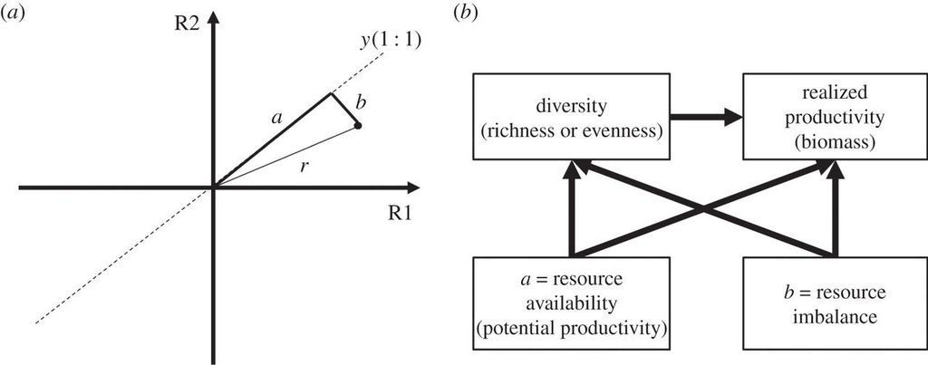

This schematic shows some site resource concentrations in resources 1 and 2, denoted by the vector $r$, projected upon a “perfectly balanced” vector denoted by $a$. The length of this projection, $a$, represents total resource supply in the system, while the orthogonal vector, $b$ represents resource imbalance.

As an aside, I think there’s an error in the caption of this figure, where $b$ is listed as a function of cosh(), which should produce an angle, $\theta$. This measure of $\theta$ is likely what is actually being used, as is the case in the original Cardinale et al 2009. I’ve listed the formula below:

$$\theta = \cos^{-1}\frac{(\vec{x} \cdot \vec{y})}{\left\lVert\vec{x}
\right\rVert \left\lVert\vec{y}\right\rVert} = \cos^{-1}\frac{a}{r}$$

I haven’t seen this done before in other publications, but I believe we can also use this information to figure out what is limiting relative to this ideal stoichiometric ratio. The vector $b$, which is the portion of our observed vector $r$ that is not accounted for by the projection onto $a$ can be termed the “rejection”, defined simply by $b = r - a$

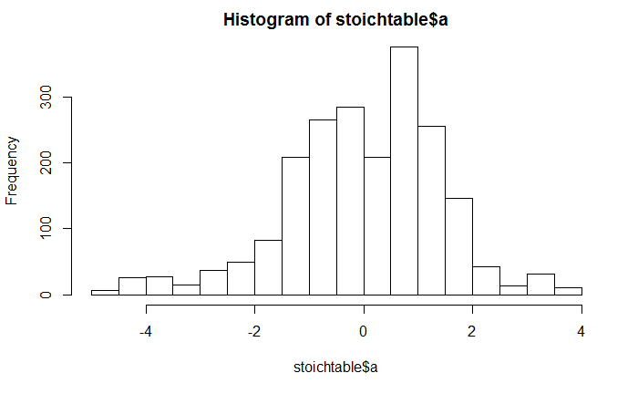